# Analisi dei successi musicali su Spotify

2024-03-01

## Argomenti trattati

- Il dataset
- Storia
- Brani
- Artisti
- Caratteristiche acustiche
- Analisi lessicale
- Grafo delle collaborazioni
- Conclusioni

## Il dataset

## Fonte dei dati

Il dataset preso in esame contiene le informazioni riguardanti le canzoni Più ascoltate su una delle piattaforme di streaming Più utilizzate al mondo: Spotify.  
Per ognuna di essere sono presenti alcune caratteristiche acustiche del brano, gli artisti e il titolo e la presenza sulle altre piattaforme.  
Le informazioni sono aggiornate ad Agosto 2023, data di pubblicazione del dataset su Kaggle.

Il dataset è reperibile al seguente indirizzo: https://www.kaggle.com/datasets/nelgiriyewithana/top-spotify-songs-2023)

## Le informazioni principali

- Nome della traccia e artisti presenti
- Numero di artisti
- Data di uscita
- Numero di streams su Spotify
- Numero di presenze in classifiche e playlist di Spotify
- Numero di presenze in classifiche e playlist di Apple Music
- Numero di presenze in classifiche e playlist di Deezer
- Numero di presenze in classifiche di Shazam
- Bpm, Chiave, Modo e Caratteristiche espressive

## Prime analisi

Alcune informazioni generali sul dataset:

```
## Sono presenti 927 canzoni
```

```
## Sono presenti 692 artisti diversi
```

```
## I brani presenti sono usciti in un periodo che va dal 1930 al 2023
```

```
## Il brano con più ascolti ne conta ben 2.135.158.446
```

## La storia

## Anno di uscita delle canzoni

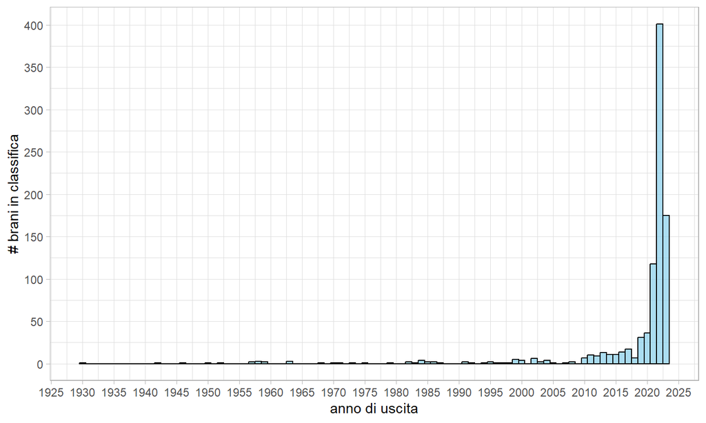

## Streams per canzone

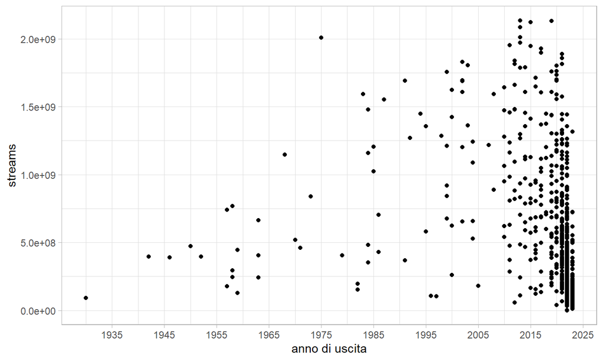

## Considerazioni

```
## L'anno con il maggior numero di brani è il 2022 con ben 401 brani
```

```
## Il numero di brani cresce al crescere del tempo
```

```
## Fa eccezzione l'anno 2018 con solo 7 brani
```

```
## Correlazione tra anno di uscita e numero di visualizzazioni: -0.2678
```

## Brani

## I 10 brani più ascoltati

```
##               Titolo        Artisti Anno    Streams
## 1  Take Me To Church         Hozier 2013 2135158446
## 2            Circles    Post Malone 2019 2132335812
## 3      Love Yourself  Justin Bieber 2015 2123309722
## 4          All of Me    John Legend 2013 2086124197
## 5     Counting Stars    OneRepublic 2013 2011464183
## 6            Riptide      Vance Joy 1975 2009094673
## 7         Wake Me Up         Avicii 2013 1970673297
## 8     Can't Hold Us      Macklemore 2011 1953533826
## 9          The Hills     The Weeknd 2015 1947371785
## 10           HUMBLE. Kendrick Lamar 2017 1929770265
```

## Presenza nelle playlist

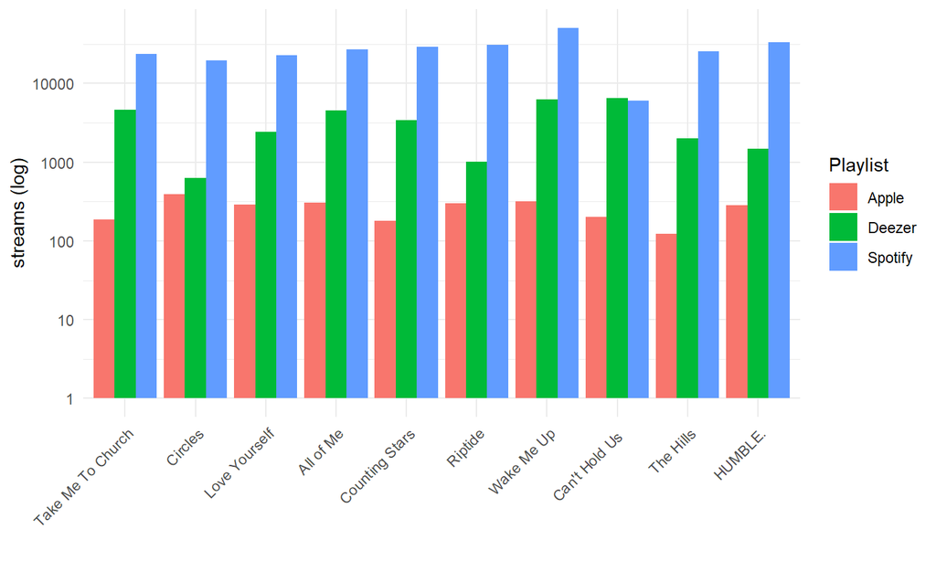

## Artisti

## I 10 artisti più presenti

```
##           Artista Principale Featuring Totale Ascolti_totali
## 1       Bad Bunny         26        14     40    23813527270
## 2    Taylor Swift         36         2     38    14630378183
## 3      The Weeknd         32         3     35    17660335990
## 4  Kendrick Lamar         23         0     23     5555903581
## 5             SZA         23         0     23     6493011189
## 6            Feid         15         6     21     5438012982
## 7           Drake         18         0     18     5329108911
## 8      Peso Pluma          5        11     16     4108521285
## 9    Harry Styles         15         0     15     6772877034
## 10      21 Savage          1        13     14     4099215953
```

## Numero di artisti per brano

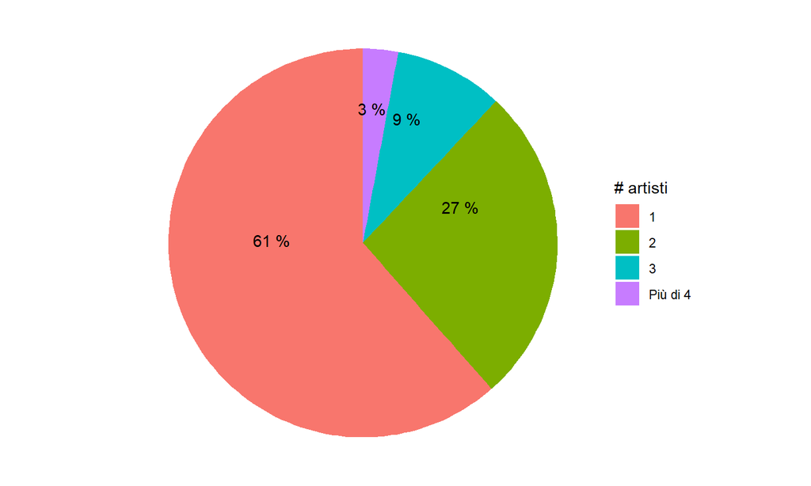

```
## La media è di 1.561 artisti per brano
```

## Ascolti medi per numero di artisti

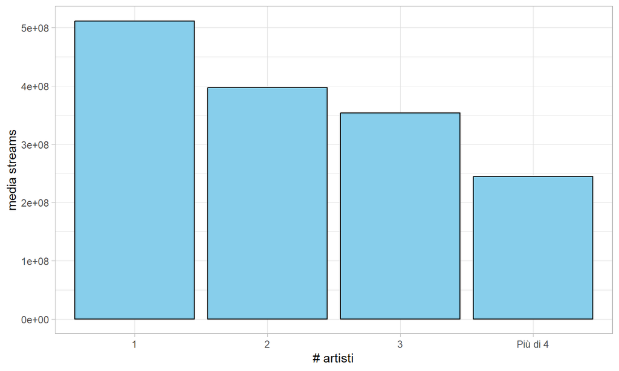

## Caratteristiche Acustiche

## Bpm nei brani

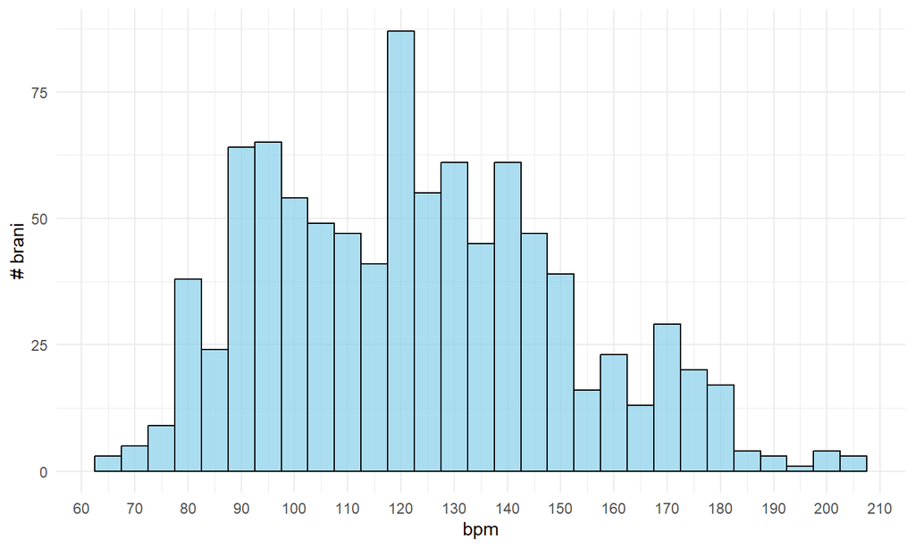

## Modalità delle canzoni

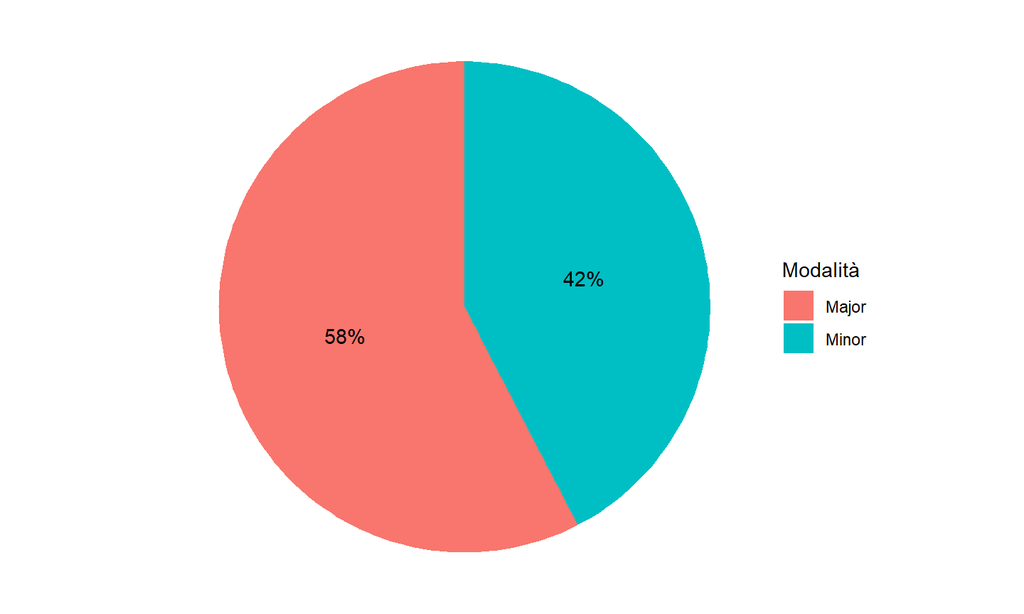

## Tonalità delle canzoni

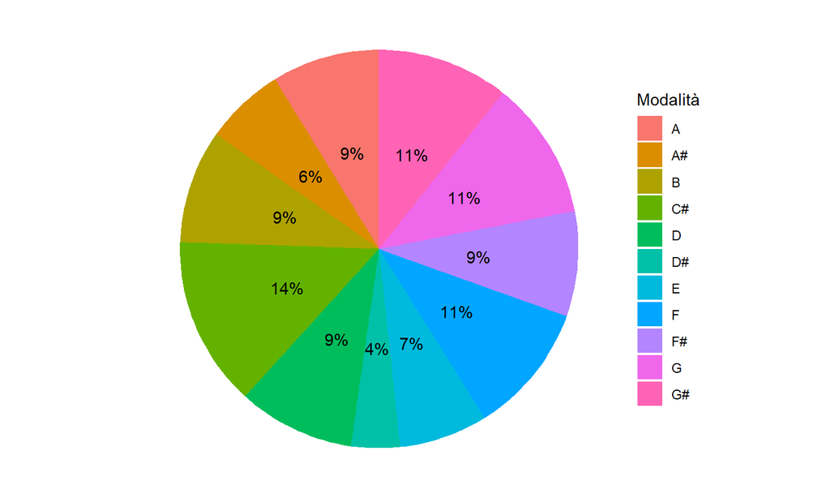

## Moda del dataset

```
## La modalità più comune è Major
```

```
## La chiave più comune è C#
```

```
## Il valore di bpm più comune (multipli di 5) è 120
```

Inoltre le combinazioni più comuni sono:

```
##   Modalità   Chiave   Bpm
## 1      Major        D    95
## 2      Major        G   120
## 3      Major       G#   120
```

## Valori medi

Si analizzano quindi la media di altre caratteristiche acustiche delle canzoni in lista

```
## Energia: 64.44337 %
```

```
## Valenza: 51.46926 %
```

```
## Acusticità: 26.93096 %
```

```
## Loquacità: 10.22546 %
```

```
## Vitalità: 18.25998 %
```

```
## Ballabilità: 67.09385 %
```

## Andamento nel tempo

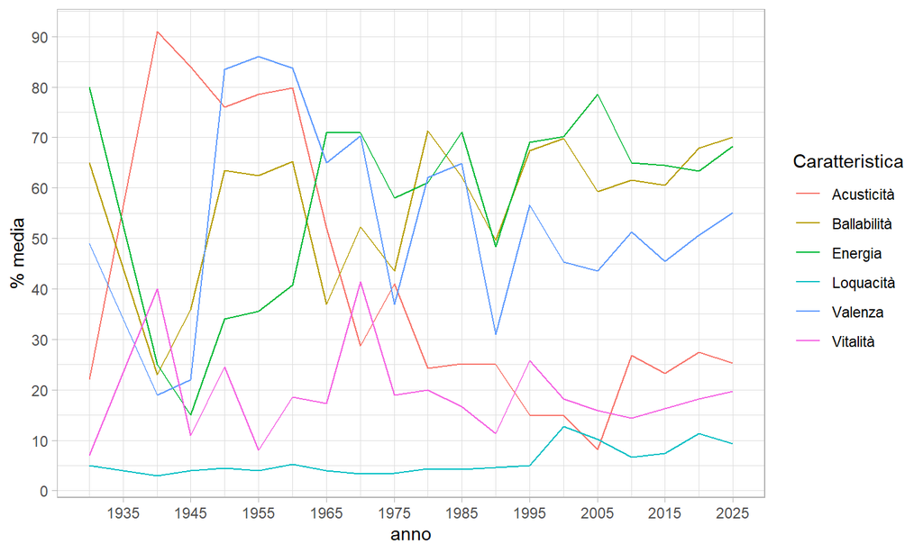

## Analisi lessicale

## Analisi dei titoli

Di seguito viene presentata una nuvola di parole che rappresenta i termini più usati.

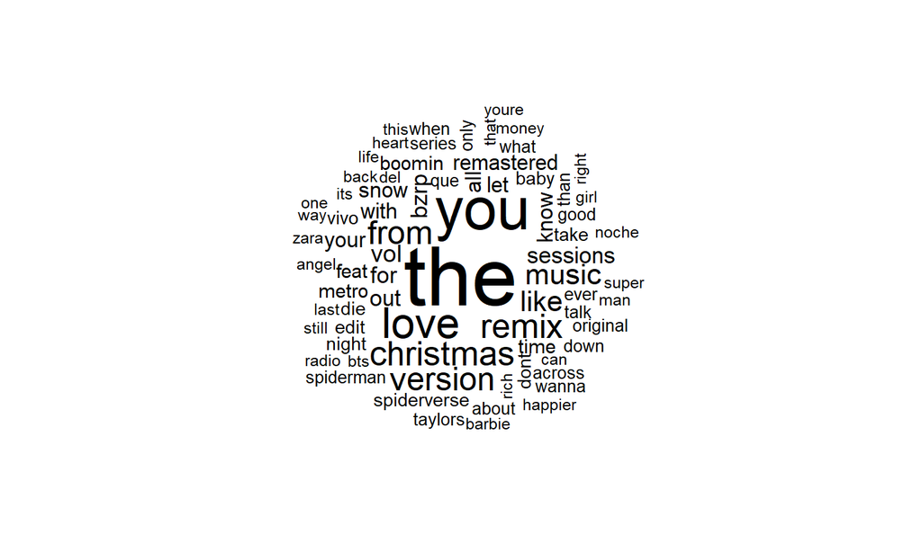

## Grafo delle collaborazioni

## Tutti gli artisti

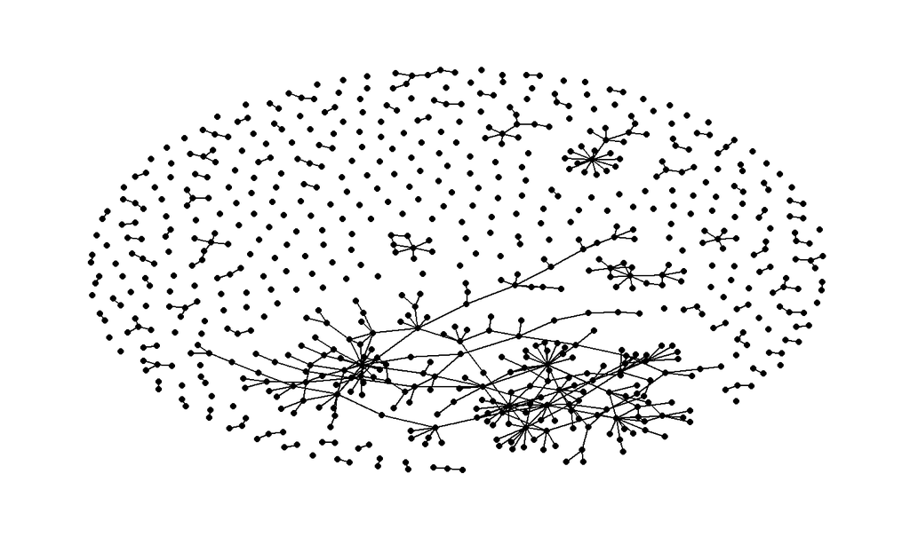

```
## I nodi non connessi a nessun altro nodo sono 202 su 692
```

## Componente gigante

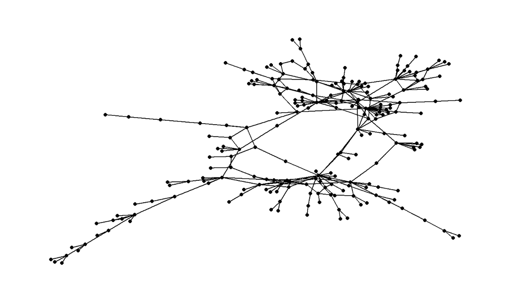

## Statistiche del grafo

Grado

```
## Media: 2.534562 valore minimo 1 valore massimo 17
```

Betweenness

```
## Media: 536.341 valore minimo 0 valore massimo 6638.017
```

Closeness

```
## Media: 8e-04 valore minimo 0.00045 valore massimo 0.00117
```

Diametro

```
## 14
```

## Cluster

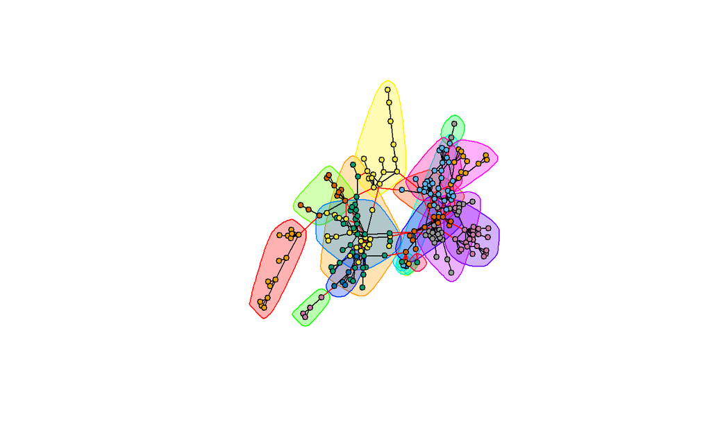

## Conclusioni

## Miglioramenti futuri

- Utilizzo di un dataset più aggiornato (kaggle)
- Ampliare il dataset, inserendo un maggior numero di brani in modo da rendere il grafo delle collaborazioni più completo e migliorare le altre analisi

## Grazie dell’attenzione!